# MScA, Bayesian Methods (32014) Week 2 Workshop

Yuri Balasanov, © iLykei 2016

# 1 References

[G] Andrew Gelman, John B. Carlin, Hal S. Stern, David B. Dunson, Aki Vehtari, Donald B. Rubin, Bayesian Data Analysis, Third Edition, 2013, Taylor & Francis Group.  
[K] John K. Kruschke, Doing Bayesian Data Analysis, A Tutorial with R, JAGS, and STAN, 2015, Elsevier.

# 2 Software Installation

Download file with R code from [web site of John Kruschke, file DBDA2Eprograms.zip](https://sites.google.com/site/doingbayesiandataanalysis/software-installation).

Follow installation instructions for the software in the book, JAGS and STAN.

When use the code from the book always make the folder with all files archived in DBDA2Eprograms.zip the working directory.

# 3 Example: Mammography Screening Controvercy

## 3.1 Problem

According to [CDC](http://www.cdc.gov/), probability of breast cancer among women of age 50-60 years old is 2.28%.  
Screening using mammography has sensitivity (i.e. probability of detecting the disease correctly) 75%-94%. Specificity of the test (i.e. probability of correct “no disease” conclusion) is 83%-98%. Assume the most optimistic parameters of the test (94% and 98%, correspondingly for sensitivity and specificity) What is the probability that randomly selected woman with positive test result has the disease?

(Do it yourself)

```r
#Prior p(theta1)
p.theta1<-.0228
#Sensitivity: p(tau1|theta1)
p.tau1.theta1<-.94
#Specificity: p(tau0|theta0)
p.tau0.theta0<-.98
#Complimentary probabilities
p.theta0<-1-p.theta1
p.tau1.theta0<-1-p.tau0.theta0
#Bayes
(p.theta1.tau1<-p.tau1.theta1*p.theta1/(p.tau1.theta1*p.theta1+p.tau1.theta0*p.theta0))
```

```
## [1] 0.5230379
```

Assume that randomly selected woman tested positive and then retested with negative test result.  
After both tests what is the probability of disease?

(Do it yourself)

```r
# Set the prior to the new probability of having the disease:
pDisease = p.theta1.tau1
# Bayes rule for second, negative test:
(p.theta1.tau0 = ( (1.0-p.tau1.theta1) * pDisease /
+ ( (1.0-p.tau1.theta1) * pDisease+ (1.0-p.tau1.theta0) * (1.0-pDisease) ) ))
```

```
## [1] 0.06291489
```

## 3.2 Comparison with FNP Statistical Approach

Example from Linear and Non-Linear Models, Lecture 4

```r
suppressWarnings(library(faraway))
data(babyfood)
babyfood
```

```
##   disease nondisease  sex   food
## 1      77        381  Boy Bottle
## 2      19        128  Boy  Suppl
## 3      47        447  Boy Breast
## 4      48        336 Girl Bottle
## 5      16        111 Girl  Suppl
## 6      31        433 Girl Breast
```

Select rows 1 and 3: boys bottle fed or breast fed.

```r
(data<-babyfood[c(1,3),c(1:2,4)])
```

```
##   disease nondisease   food
## 1      77        381 Bottle
## 3      47        447 Breast
```

### 3.2.1 FNP-Approach

The simplest way of analysis, as we learned, was to use the prop test.  
It means:

- Creating 2 proportions:
1. 77 diseases out of 458 for bottle-fed baby boys
2. 47 diseases out of 494 for breast-fed baby boys
- Comparing the proportions and testing $H_0:~p_1=p_2$

```r
prop.test(as.matrix(data[,1:2]))
```

```
##
##  2-sample test for equality of proportions with continuity
##  correction
##
## data:  as.matrix(data[, 1:2])
## X-squared = 10.539, df = 1, p-value = 0.001169
## alternative hypothesis: two.sided
## 95 percent confidence interval:
##  0.02795236 0.11800878
## sample estimates:
##    prop 1    prop 2
## 0.1681223 0.0951417
```

The null hypothesis is rejected.

Then we use logistic regression to find out how much the odds of having the disease change between bottle-fed and breast-fed babies.

```r
mdl<-glm(cbind(disease,nondisease)~food,family=binomial,data)
summary(mdl)
```

```
##
## Call:
## glm(formula = cbind(disease, nondisease) ~ food, family = binomial,
##     data = data)
##
## Deviance Residuals:
## [1]  0  0
##
## Coefficients:
##             Estimate Std. Error z value Pr(>|z|)
## (Intercept)  -1.5990     0.1249 -12.797  < 2e-16 ***
## foodBreast   -0.6534     0.1978  -3.303 0.000955 ***
## ---
## Signif. codes:  0 '***' 0.001 '**' 0.01 '*' 0.05 '.' 0.1 ' ' 1
##
## (Dispersion parameter for binomial family taken to be 1)
##
##     Null deviance:  1.1235e+01  on 1  degrees of freedom
## Residual deviance: -1.7097e-14  on 0  degrees of freedom
## AIC: 15.591
##
## Number of Fisher Scoring iterations: 3
```

Take exponents to express the change in odds ratio, rather than log of it.

```r
exp(mdl$coefficients)
```

```
## (Intercept)  foodBreast
##   0.2020997   0.5202650
```

Look at confidence intervals to see the significance and the range of accuracy of our conclusions.

```r
suppressWarnings(library(MASS))
exp(confint(mdl))
```

```
##                 2.5 %    97.5 %
## (Intercept) 0.1570976 0.2565573
## foodBreast  0.3511082 0.7636948
```

### 3.2.2 B-Approach

#### 3.2.2.1 Not a true B-approach

First, address the same question not exactly within Bayesian approach, but with the help of Bayes theorem.

Create joint distribution of two binary variables: (“disease”,“nondisease”) and (“bottle”,“breast”).

```r
joint.dist<-data
joint.dist[1:2,1:2]<-joint.dist[1:2,1:2]/sum(joint.dist[1:2,1:2])
joint.dist
```

```
##      disease nondisease   food
## 1 0.08088235  0.4002101 Bottle
## 3 0.04936975  0.4695378 Breast
```

```r
sum(joint.dist[1:2,1:2])
```

```
## [1] 1
```

Find marginal probabilities for the disease and the treatment.

```r
(p.breast<-sum(joint.dist[2,-3]))
```

```
## [1] 0.5189076
```

```r
(p.disease<-sum(joint.dist[,1]))
```

```
## [1] 0.1302521
```

Find conditional probability of breastfeeding, given that baby got the disease
$$p(breast|disease)=\frac{p(breast,disease)}{p(disease)}.$$

```r
(p.breast.disease<-joint.dist[2,1]/p.disease)
```

```
## [1] 0.3790323
```

Finally, use Bayes theorem.

```r
(p.disiease.breast<-p.breast.disease*p.disease/p.breast)
```

```
## [1] 0.0951417
```

Could we calculate the same probability directly, not using Bayes theorem?

```r
(p.disiease.breast<-joint.dist[2,1]/p.breast)
```

```
## [1] 0.0951417
```

**Why one would prefer using Bayes theorem rather than calculating the probability disrectly?**

**This is not Bayesian approach. Why?**

#### 3.2.2.2 True B-approach but for a different problem

True Bayesian approach to the baby food problem would be logistic regression with the food type as a predictor and prior distribution for the parameters.

We will look at this model later.

Now use the true B-approach to estimation of probability of binomial distribution.

The data collected from observation of 952 baby boys of which 124 got the disease: this is a sequence of 124 ones and 828 zeros.

```r
(Data<-c(rep(0,828),rep(1,124)))
```

[output not shown]

Probability of success is $p$.  
In the FNP-approach its estimate is $\hat{p}$.  
In the B-approach it is a random variable with prior distribution density $f_p(x)$.  
Then the B-approach means using Bayes theorem to find posterior $f_p(p|Data)$.  
We will practice this approach in the following section.

# 4 Example of Using Bayes Theorem in Statistics

The following example uses script BernGrid.R from the book by John K. Kruschke.

Source the scripts `DBDA2E-utilities.R` and `BernGrid.R` available on the [book site](https://sites.google.com/site/doingbayesiandataanalysis/software-installation).

```r
#graphics.off()
suppressWarnings(source(paste(dataPath,"DBDA2E-utilities.R",sep="/")))
```

```
##
## Kruschke, J. K. (2015). Doing Bayesian Data Analysis, Second Edition:
## A Tutorial with R, JAGS, and Stan. Academic Press / Elsevier.
```

```r
source(paste(dataPath,"BernGrid.R",sep="/"))
```

Set the parameters for Graph 5.1 on page 111. Vector $\theta$ is probability of success in Bernoulli trials, it can take 5 values from 0 to 1.  
Vector `pTheta` is the prior distribution of triangular shape.  
Variable `Data` is the observed number of successes $\gamma$. Start with one flip in which $\gamma=1$.  
Likelihood function for Bernoulli trials is $p(\gamma | \theta)= \theta^{\gamma} (1-\theta)^{(1-\gamma)}$. Posterior distribution is obtained from Bayes theorem.  
Numerator in the expression is the product of `pTheta` and likelihood.  
The simplest way of finding the denominator is to sum the numerator vector. This will make posterior probabilities add up to 1.  
Calculate the values of likelihood `likelihood` and posterior distribution `post` yourself, then run `BenGrid()` and compare the results.

Set $\theta$, the prior and the data.

```r
(Theta = seq( 0 , 1 , length=5 ))  # Sparse teeth for Theta.
```

```
## [1] 0.00 0.25 0.50 0.75 1.00
```

```r
pTheta = pmin( Theta , 1-Theta ) # Triangular shape for pTheta.
(pTheta = pTheta/sum(pTheta))      # Make pTheta sum to 1.0
```

```
## [1] 0.00 0.25 0.50 0.25 0.00
```

```r
Data = c(rep(0,0),rep(1,1))      # Single flip with 1 head
```

Function `pmin()` returns parallel minimum, i.e. minimum of 2 vectors `Theta` and `1-Theta` by position.

Calculate likelihood and posterior.

(Do it yourself)

```r
likelihood=Theta^Data * (1-Theta)^(1-Data)
post=pTheta*likelihood
post=post/sum(post)
```

Compare the results, make the plot.

```r
likelihood
```

```
## [1] 0.00 0.25 0.50 0.75 1.00
```

```r
post
```

```
## [1] 0.000 0.125 0.500 0.375 0.000
```

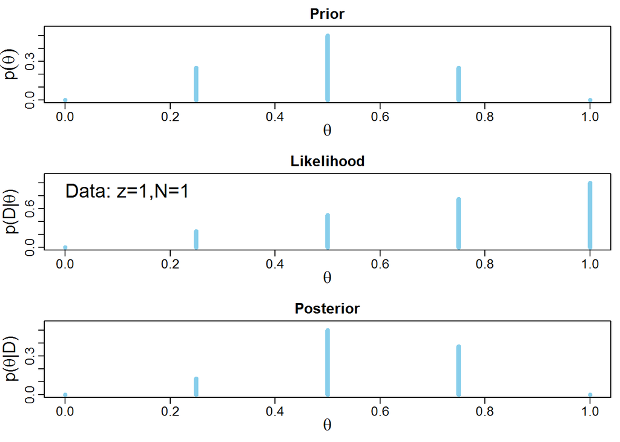

```
## [1] 0.000 0.125 0.500 0.375 0.000
```

```r
#openGraph(width=5,height=7)
(posterior = BernGrid( Theta, pTheta , Data , plotType="Bars" ,
                      showCentTend="None" , showHDI=FALSE , showpD=FALSE ))
```

```r
#saveGraph(file="BernGridExample0",type="eps")
#------------------------------------------------------------------------------
```

## 4.2 Binomial model, triangular prior with 11 values

Increase the number of values taken by $\theta$ to 11.

```r
Theta = seq( 0 , 1 , length=11 )  # Sparse teeth for Theta.
pTheta = pmin( Theta , 1-Theta ) # Triangular shape for pTheta.
pTheta = pTheta/sum(pTheta)      # Make pTheta sum to 1.0
Data = c(rep(0,0),rep(1,1))      # Single flip with 1 head
```

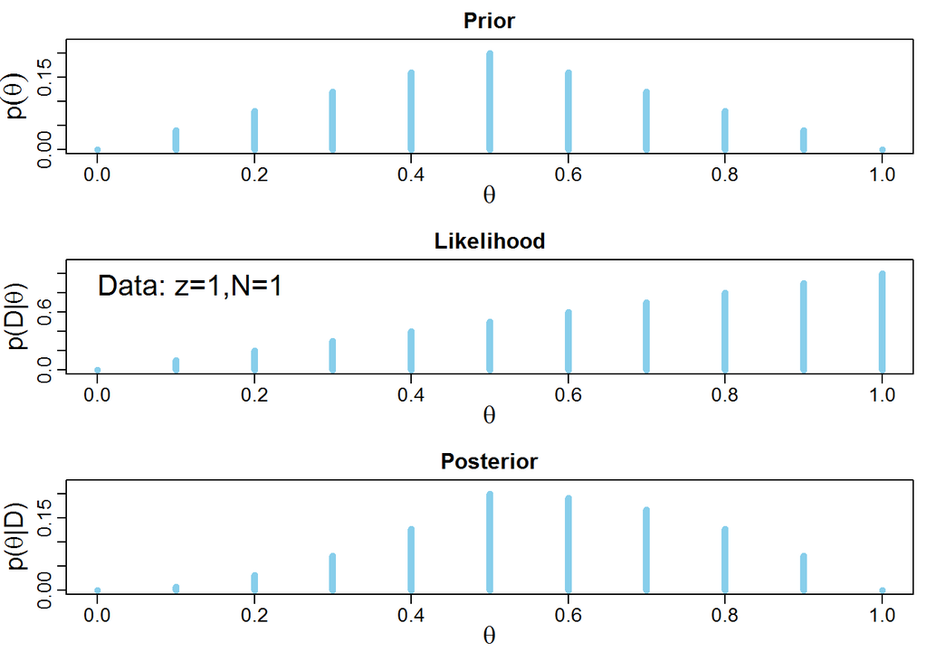

```r
#openGraph(width=5,height=7)
posterior = BernGrid( Theta, pTheta , Data , plotType="Bars" ,
                      showCentTend="None" , showHDI=FALSE , showpD=FALSE )
```

```r
#saveGraph(file="BernGridExample1",type="eps")
#------------------------------------------------------------------------------
```

**Which of the functions has more influence on the posterior: prior or likelihood?**

## 4.3 Binomial model, uniform prior with 1001 values

Increase the number of values of $\theta$ to 1001. Make prior uniform on [0,1].

(Do it yourself)

```r
Theta = seq( 0 , 1 , length=1001 ) # Fine teeth for Theta.
pTheta = rep(1,length(Theta))      # Uniform (horizontal) shape for pTheta.
pTheta = pTheta/sum(pTheta)        # Make pTheta sum to 1.0
Data = c(rep(0,0),rep(1,1))        # Single flip with 1 head
```

**Which of the functions has more influence on the posterior: prior or likelihood?**

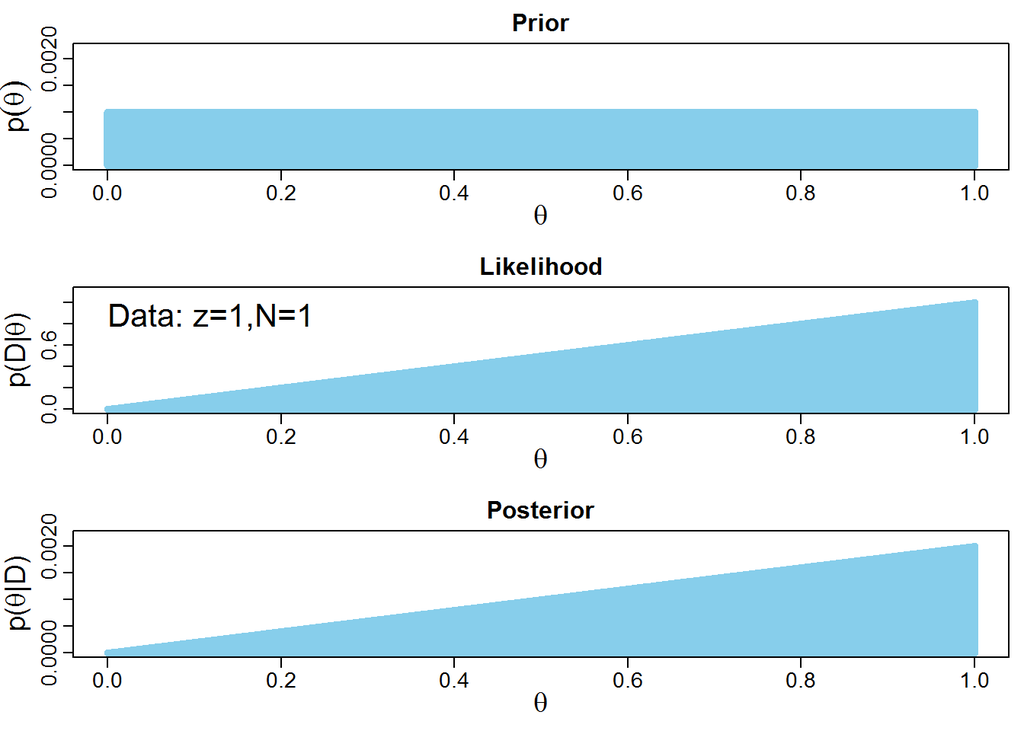

```r
#openGraph(width=5,height=7)
posterior = BernGrid( Theta, pTheta , Data , plotType="Bars" ,
                      showCentTend="None" , showHDI=FALSE , showpD=FALSE )
```

```r
#saveGraph(file="BernGridExample2",type="eps")
#------------------------------------------------------------------------------
```

## 4.4 Binomial model, binary prior with values 0, 1

Make prior distribution giving probabilities 0.5 to $\theta=0,1$ and probabilities 0 to all other values of $\theta$.

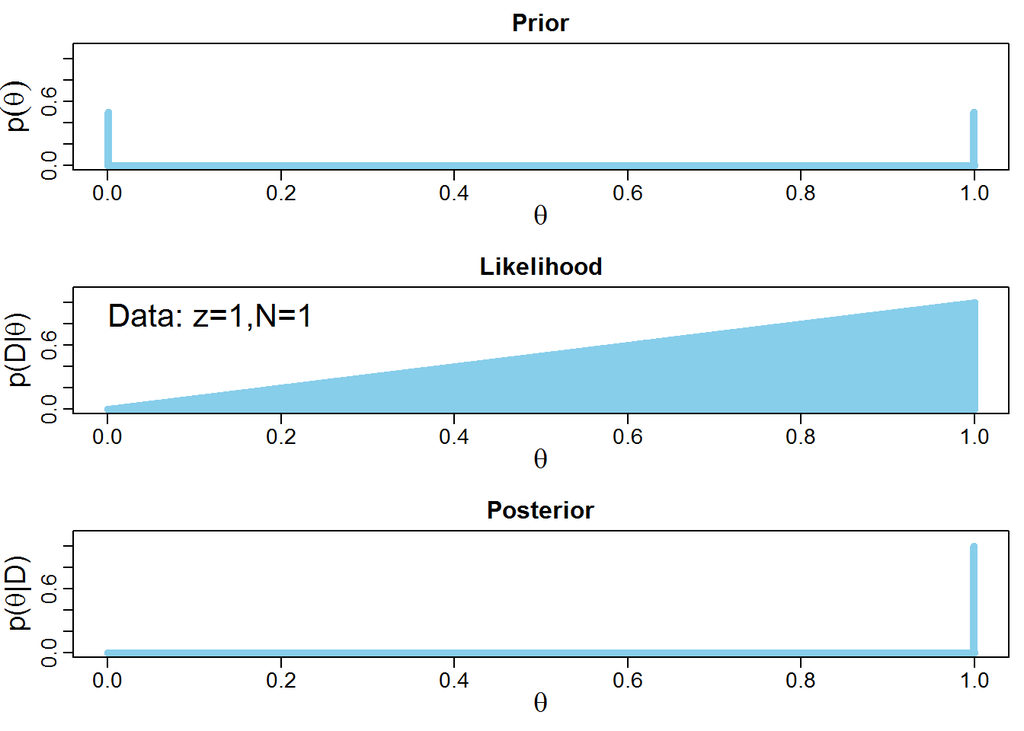

```r
Theta = seq( 0 , 1 , length=1001 ) # Fine teeth for Theta.
pTheta = rep(0,length(Theta))      # Only extremes are possible!
pTheta[2] = 1                      # Only extremes are possible!
pTheta[length(pTheta)-1] = 1
pTheta = pTheta/sum(pTheta)        # Make pTheta sum to 1.0
Data = c(rep(0,0),rep(1,1))        # Single flip with 1 head

#openGraph(width=5,height=7)
posterior = BernGrid( Theta, pTheta , Data , plotType="Bars" ,
                      showCentTend="None" , showHDI=FALSE , showpD=FALSE )
```

```r
#saveGraph(file="BernGridExample3",type="eps")
#------------------------------------------------------------------------------
```

Compromise between the prior and likelihood resulted in concentration of the posterior at the observed value (maximum likelihood).

## 4.5 Binomial model, triangular prior with 1001 values, 4 observations

Make prior with triangular shape.  
Make the number of Bernoulli trials equal to 4, of which one outcome is Head ($\gamma = 1$) and three outcomes are Tails.  
Calculate likelihood and posterior yourself, compare with `BernGrid()`.

```r
Theta = seq( 0 , 1 , length=1001 )  # Fine teeth for Theta.
pTheta = pmin( Theta , 1-Theta ) # Triangular shape for pTheta.
pTheta = pTheta/sum(pTheta)      # Make pTheta sum to 1.0
Data = c(rep(0,3),rep(1,1))      # 25% heads, N=4
```

(Do it yourself)

```r
likelihood=Theta^sum(Data) * (1-Theta)^(4-sum(Data))
post=pTheta*likelihood
post=post/sum(post)
```

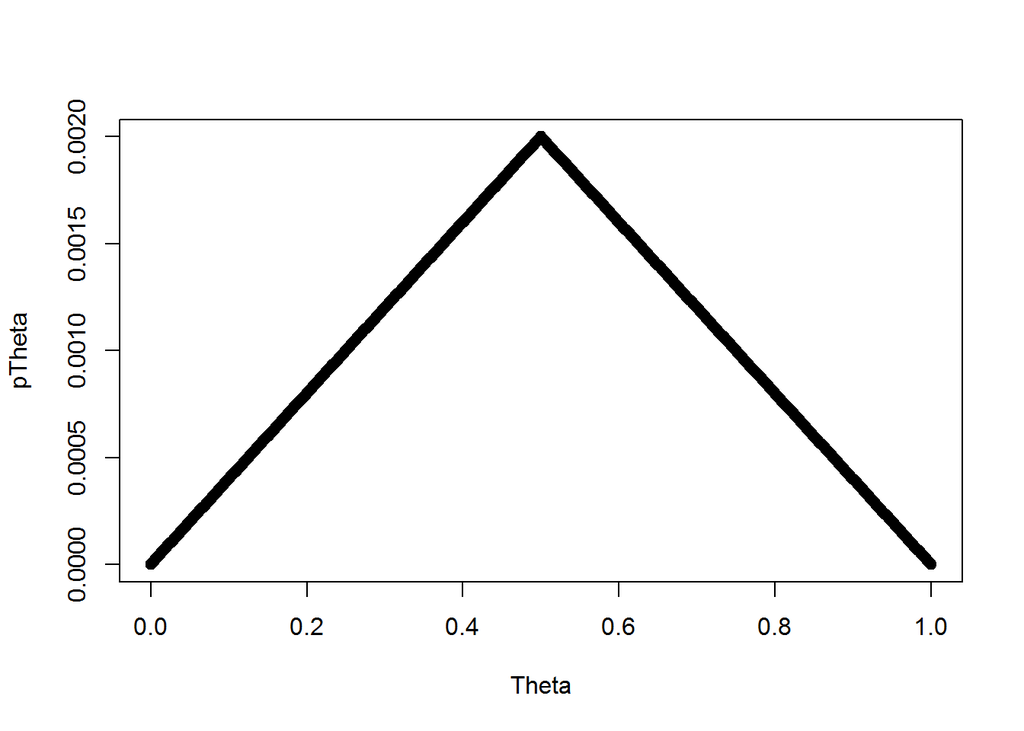

```r
plot(Theta,pTheta)
```

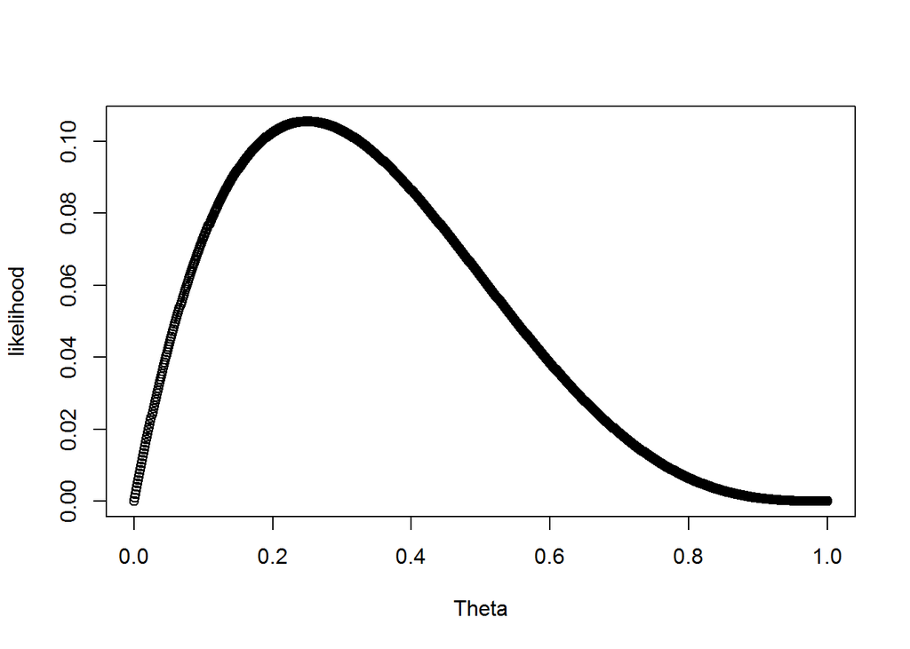

```r
plot(Theta,likelihood)
```

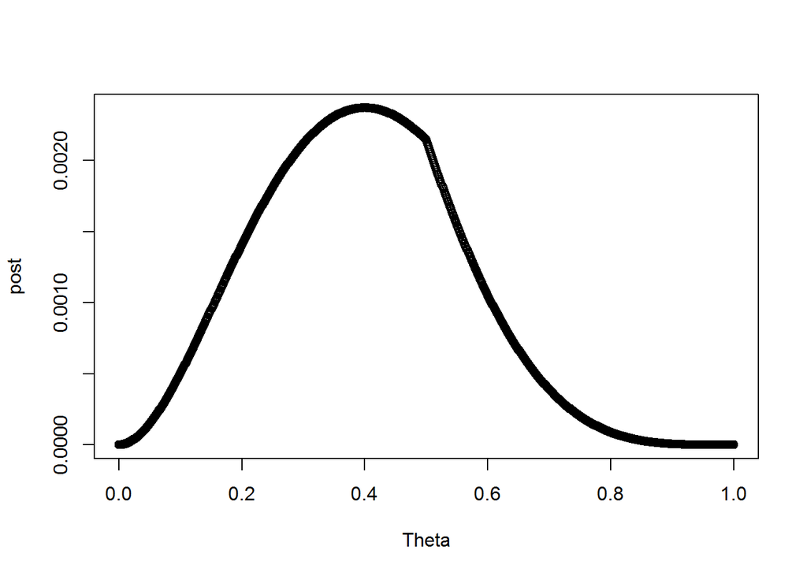

```r
plot(Theta,post)
```

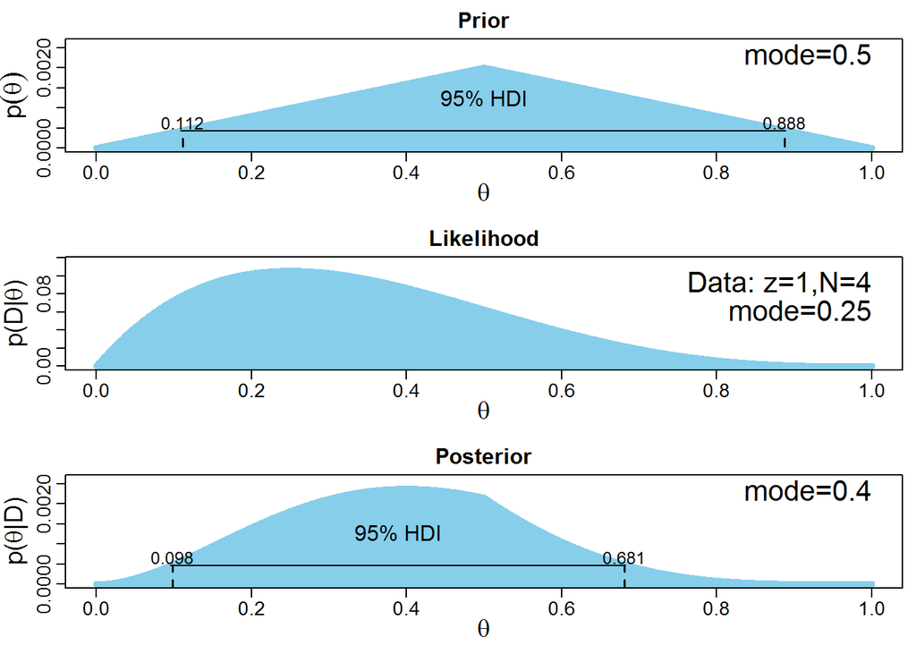

```r
#openGraph(width=5,height=7)
posterior = BernGrid( Theta, pTheta , Data , plotType="Bars" ,
                      showCentTend="Mode" , showHDI=TRUE , showpD=FALSE )
```

```r
#saveGraph(file="BernGridExample4",type="eps")
#------------------------------------------------------------------------------
```

## 4.6 Binomial model, concentrated prior, 4 observations

Make the prior concentrated at 0.5 by taking it to the power of 10.

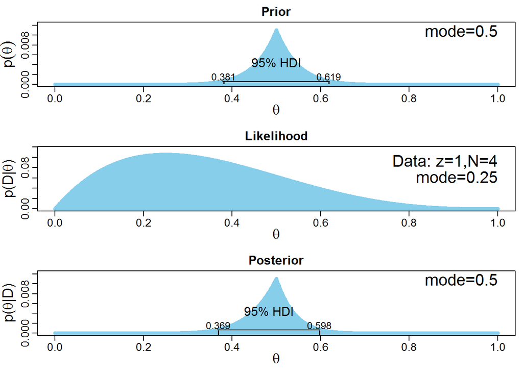

```r
Theta = seq( 0 , 1 , length=1001 )  # Fine teeth for Theta.
pTheta = pmin( Theta , 1-Theta ) # Triangular shape for pTheta.
pTheta = pTheta/sum(pTheta)      # Make pTheta sum to 1.0
pTheta = pTheta^10               # Sharpen pTheta !
pTheta = pTheta/sum(pTheta)      # Make pTheta sum to 1.0
Data = c(rep(0,3),rep(1,1))      # 25% heads, N=4

#openGraph(width=5,height=7)
posterior = BernGrid( Theta, pTheta , Data , plotType="Bars" ,
                      showCentTend="Mode" , showHDI=TRUE , showpD=FALSE )
```

```r
#saveGraph(file="BernGridExample5",type="eps")
#------------------------------------------------------------------------------
```

**Which of the functions has more influence on the posterior: prior or likelihood?**

## 4.7 Binomial model, dispersed prior, 4 observations

Smear the prior to almost flat shape by taking `pTheta` to the power of 0.1.

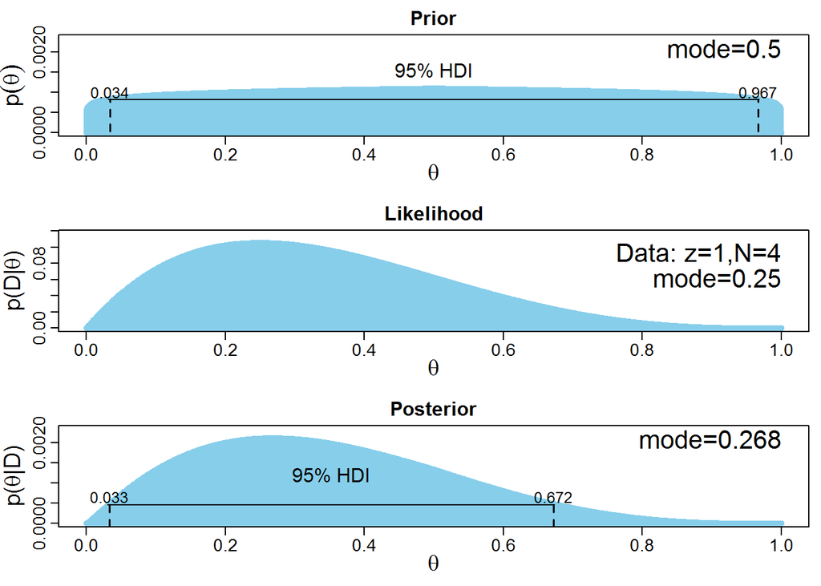

```r
Theta = seq( 0 , 1 , length=1001 )  # Fine teeth for Theta.
pTheta = pmin( Theta , 1-Theta ) # Triangular shape for pTheta.
pTheta = pTheta/sum(pTheta)      # Make pTheta sum to 1.0
pTheta = pTheta^0.1              # Flatten pTheta !
pTheta = pTheta/sum(pTheta)      # Make pTheta sum to 1.0
Data = c(rep(0,3),rep(1,1))      # 25% heads, N=4

#openGraph(width=5,height=7)
posterior = BernGrid( Theta, pTheta , Data , plotType="Bars" ,
                      showCentTend="Mode" , showHDI=TRUE , showpD=FALSE )
```

```r
#saveGraph(file="BernGridExample6",type="eps")
#------------------------------------------------------------------------------
```

**Which of the functions has more influence on the posterior: prior or likelihood?**

## 4.8 Binomial model, triangular prior, 40 observations

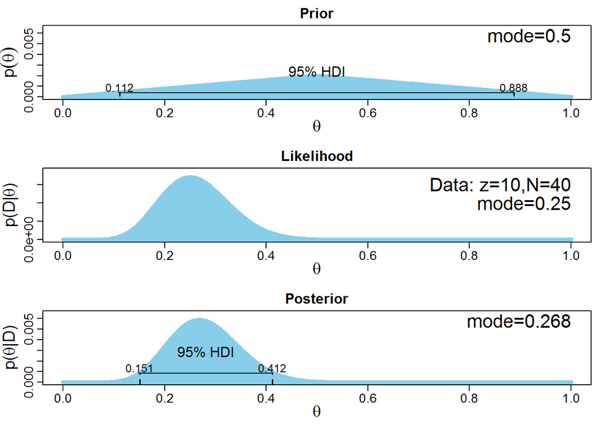

```r
Theta = seq( 0 , 1 , length=1001 )  # Fine teeth for Theta.
pTheta = pmin( Theta , 1-Theta ) # Triangular shape for pTheta.
pTheta = pTheta/sum(pTheta)      # Make pTheta sum to 1.0
Data = c(rep(0,30),rep(1,10))    # 25% heads, N=40

#openGraph(width=5,height=7)
posterior = BernGrid( Theta, pTheta , Data , plotType="Bars" ,
                      showCentTend="Mode" , showHDI=TRUE , showpD=FALSE )
```

```r
#saveGraph(file="BernGridExample7",type="eps")
#------------------------------------------------------------------------------
```

**How did the influence of the prior and the likelihood change?**

## 4.9 Binomial model, concentrated prior, 40 observations

With the same number and ratio of observations make the prior condensed around 0.5.

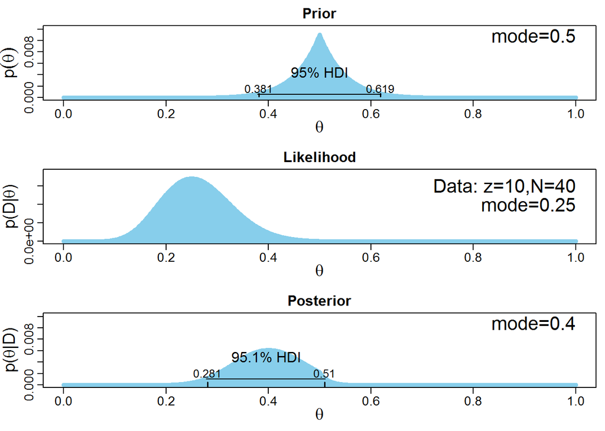

```r
Theta = seq( 0 , 1 , length=1001 )  # Fine teeth for Theta.
pTheta = pmin( Theta , 1-Theta ) # Triangular shape for pTheta.
pTheta = pTheta/sum(pTheta)      # Make pTheta sum to 1.0
pTheta = pTheta^10               # Sharpen pTheta !
pTheta = pTheta/sum(pTheta)      # Make pTheta sum to 1.0
Data = c(rep(0,30),rep(1,10))    # 25% heads, N=40

#openGraph(width=5,height=7)
posterior = BernGrid( Theta, pTheta , Data , plotType="Bars" ,
                      showCentTend="Mode" , showHDI=TRUE , showpD=FALSE )
```

```r
#saveGraph(file="BernGridExample8",type="eps")
#------------------------------------------------------------------------------
```

## 4.10 Binomial model, flat prior, 40 observations

Flatten the prior, given the same data.

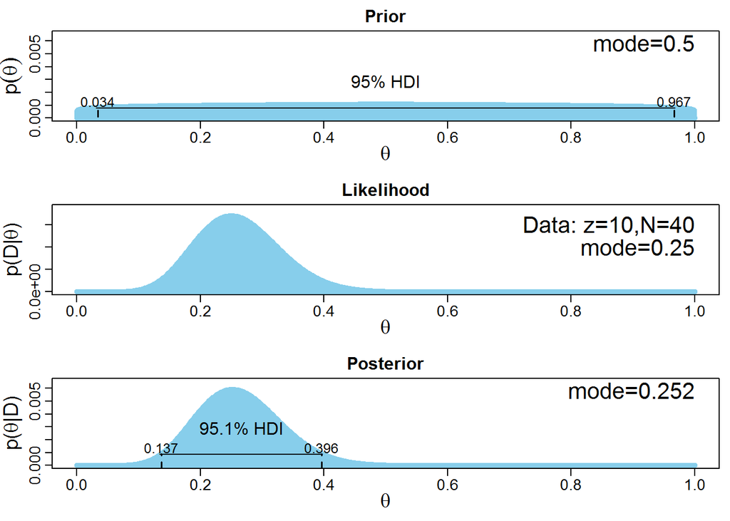

```r
Theta = seq( 0 , 1 , length=1001 )  # Fine teeth for Theta.
pTheta = pmin( Theta , 1-Theta ) # Triangular shape for pTheta.
pTheta = pTheta/sum(pTheta)      # Make pTheta sum to 1.0
pTheta = pTheta^0.1              # Flatten pTheta !
pTheta = pTheta/sum(pTheta)      # Make pTheta sum to 1.0
Data = c(rep(0,30),rep(1,10))    # 25% heads, N=40

#openGraph(width=5,height=7)
posterior = BernGrid( Theta, pTheta , Data , plotType="Bars" ,
                      showCentTend="Mode" , showHDI=TRUE , showpD=FALSE )
```

```r
#saveGraph(file="BernGridExample9",type="eps")
#------------------------------------------------------------------------------
```

## 4.11 Binomial model, bimodal prior, 27 observations

Make the prior bimodal, the data generated by 27 Bernoulli trials with 13 tails and 14 heads.

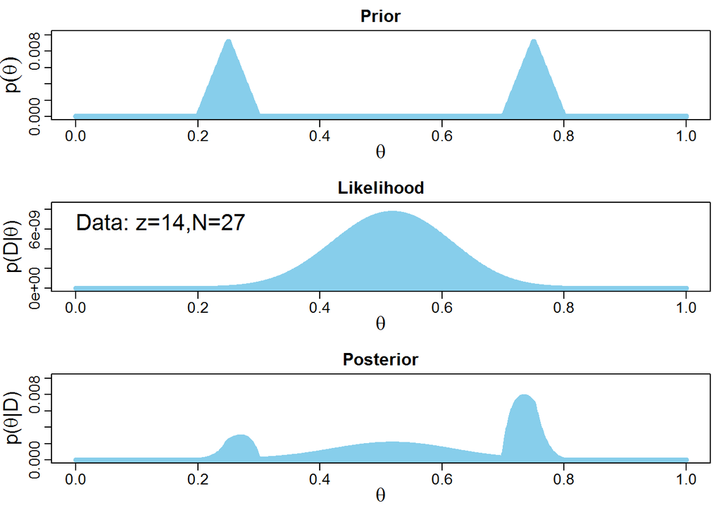

```r
Theta = seq( 0 , 1 , length=1000 )  # Fine teeth for Theta.
# Two triangular peaks on a small non-zero floor:
pTheta = c( rep(1,200),seq(1,100,length=50),seq(100,1,length=50),rep(1,200) ,
            rep(1,200),seq(1,100,length=50),seq(100,1,length=50),rep(1,200) )
pTheta = pTheta/sum(pTheta)      # Make pTheta sum to 1.0
Data = c(rep(0,13),rep(1,14))

#openGraph(width=5,height=7)
posterior = BernGrid( Theta, pTheta , Data , plotType="Bars" ,
                      showCentTend="None" , showHDI=FALSE , showpD=FALSE )
```

```r
#saveGraph(file="BernGridExample10",type="eps")
#------------------------------------------------------------------------------
par(mfrow=c(1,1))
```

# 5 Posterior distribution by simulation. Updating prior and adding new data

Look again at the example in section 4.3. with uniform prior.

Follow the steps of obtaining posterior distribution by Monte Carlo.

Define likelihood function for binomial distribution.

```r
likeli<-function(par,data){
  sdata<-sum(data)
  ldata<-length(data)
  return(par^sdata*(1-par)^(ldata-sdata))
}
```

Define values of parameter $\theta$ and prior distribution.

(Do it yourself)

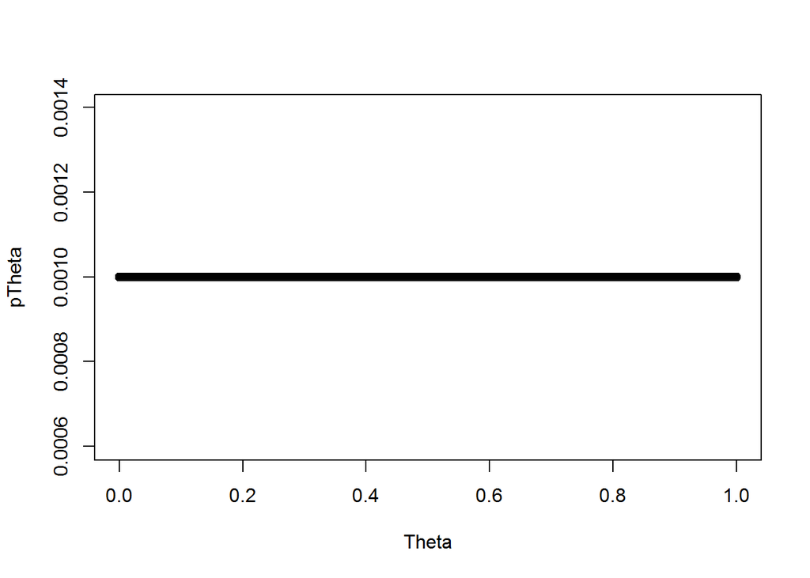

```r
Theta = seq( .00001 , 1-.00001 , length=1001 ) # Fine teeth for Theta.
pTheta = rep(1,length(Theta))      # Uniform (horizontal) shape for pTheta.
pTheta = pTheta/sum(pTheta)        # Make pTheta sum to 1.0
plot(Theta,pTheta)
```

Create data of length 5 generated by the model with parameter 0.84.

```r
set.seed(5)
(Data<-rbinom(5,size=1,prob=.84))
```

```
## [1] 1 1 0 1 1
```

Create sample of $\theta$ generated from the prior distribution.

```r
set.seed(15)
priorInd<-sample(1:length(Theta),500,replace = T)
priorSample<-cbind(Theta=Theta[priorInd],Prob=pTheta[priorInd])
priorSample<-rbind(priorSample,
                   c(head(Theta,1),head(pTheta,1)),
                   c(tail(Theta,1),tail(pTheta,1)))
```

Calculate likelihood for each simulated $\theta$ and the data.

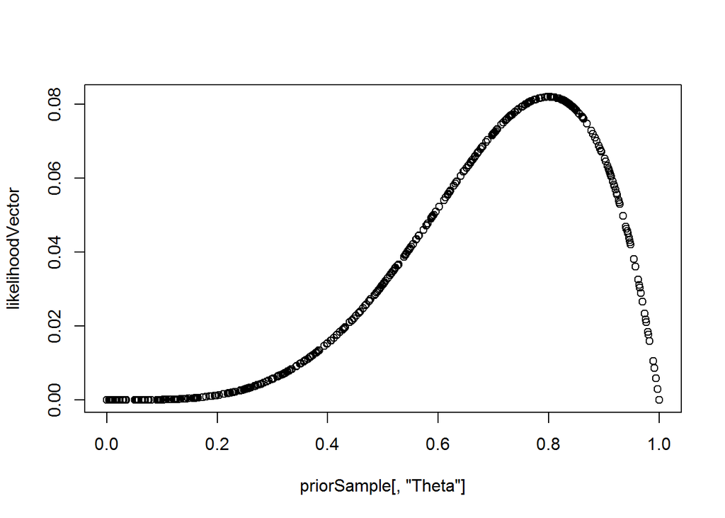

```r
likelihoodVector<-sapply(priorSample[,"Theta"],function(z) likeli(z,Data))
plot(priorSample[,"Theta"],likelihoodVector)
```

Calculate posterior distribution.

- Calculate vector of numerators of the Bayes theorem
- Normalize it
- Create function for linear interpolation of vector of numerator

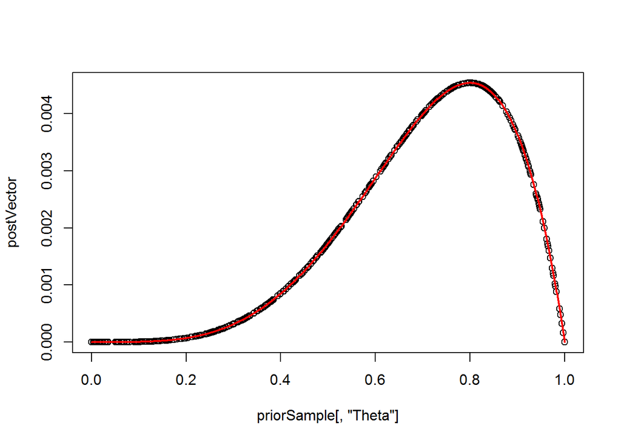

```r
postVector<-priorSample[,"Prob"]*likelihoodVector
postVector<-postVector/sum(postVector)
plot(priorSample[,"Theta"],postVector)

postDistr<-approxfun(priorSample[,"Theta"],postVector,method="linear")
plot(priorSample[,"Theta"],postVector)
lines(Theta,postDistr(Theta),col="red",lwd=2)
```

```r
length(postDistr(Theta))
```

```
## [1] 1001
```

```r
postDistr1<-postDistr(Theta)
```

Calculate mode, mean and variance of the posterior distribution.

```r
(mode1<-Theta[which.max(postDistr(Theta))])
```

```
## [1] 0.798994
```

```r
(mean1<-Theta%*%postDistr(Theta)/sum(postDistr(Theta)))
```

```
##           [,1]
## [1,] 0.7142734
```

```r
(var1<-((Theta-mean1)^2)%*%postDistr(Theta)/sum(postDistr(Theta)))
```

```
##            [,1]
## [1,] 0.02551116
```

Replace prior distribution with the posterior distribution and generate new data.

```r
set.seed(25)
pTheta<-postDistr(Theta)/sum(postDistr(Theta))
(Data<-rbinom(5,size=1,prob=.84))
```

```
## [1] 1 1 1 0 1
```

Repeat the steps of estimation.

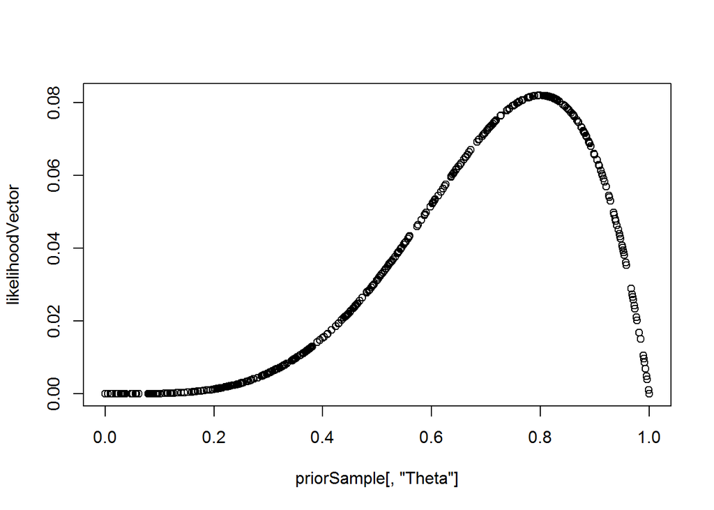

```r
set.seed(35)
priorInd<-sample(1:length(Theta),500,replace = T)
priorSample<-cbind(Theta=Theta[priorInd],Prob=pTheta[priorInd])
priorSample<-rbind(priorSample,
                   c(head(Theta,1),head(pTheta,1)),
                   c(tail(Theta,1),tail(pTheta,1)))

likelihoodVector<-sapply(priorSample[,"Theta"],function(z) likeli(z,Data))
plot(priorSample[,"Theta"],likelihoodVector)
```

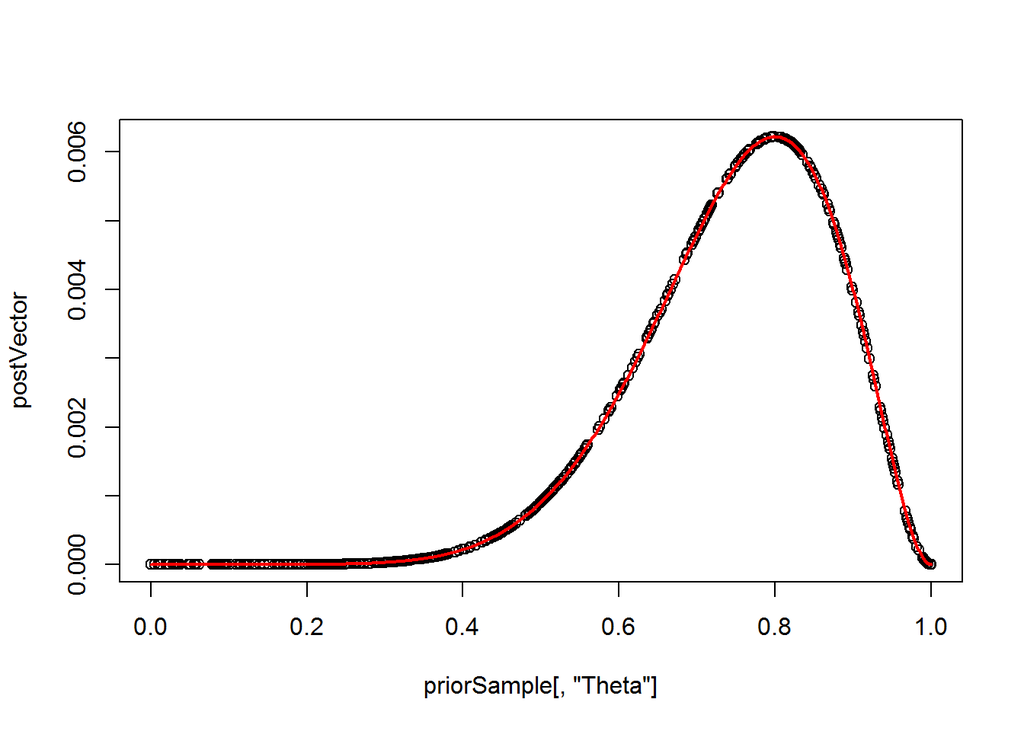

```r
postVector<-priorSample[,"Prob"]*likelihoodVector
postVector<-postVector/sum(postVector)
plot(priorSample[,"Theta"],postVector)

postDistr<-approxfun(priorSample[,"Theta"],postVector,method="linear")
plot(priorSample[,"Theta"],postVector)
lines(Theta,postDistr(Theta),col="red",lwd=2)
```

```r
postDistr2<-postDistr(Theta)
```

Calculate mode, mean and variance of the new posterior distribution.

```r
(mode2<-Theta[which.max(postDistr(Theta))])
```

```
## [1] 0.797994
```

```r
(mean2<-Theta%*%postDistr(Theta)/sum(postDistr(Theta)))
```

```
##           [,1]
## [1,] 0.7499931
```

```r
(var2<-((Theta-mean2)^2)%*%postDistr(Theta)/sum(postDistr(Theta)))
```

```
##            [,1]
## [1,] 0.01442628
```

Compare the two posteriors.

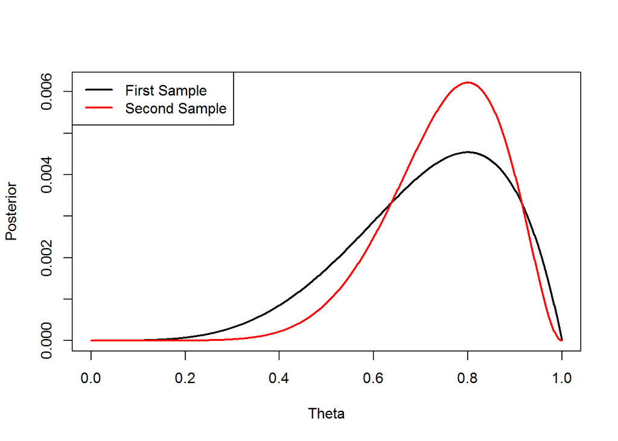

```r
matplot(Theta,cbind(postDistr1,postDistr2),type="l",lty=1,ylab="Posterior",lwd=2)
legend("topleft",legend=c("First Sample","Second Sample"),lty=1,col=c("black","red"),lwd=2)
```

# 6 Example: Expressing prior knowledge as beta distribution

This is example from Section 6.4.1 of [K].  
It uses the author’s script `BernBetaExample.R`.

```r
source(paste(dataPath,"DBDA2E-utilities.R",sep="/"))  # Load definitions of graphics functions etc.
```

```
##
## Kruschke, J. K. (2015). Doing Bayesian Data Analysis, Second Edition:
## A Tutorial with R, JAGS, and Stan. Academic Press / Elsevier.
```

```r
source(paste(dataPath,"BernBeta.R",sep="/"))          # Load the definition of the BernBeta function
```

## 6.1 Situation 1.

A coin known to be regular gets 20 flips of which 17 or 85% are heads.  
Despite this there is a **strong prior belief that the coin is fair with concentration of 500 observations**. What is your posterior believe about the probability of heads?

Express prior belief in terms of parameters of beta distribution.

(Do it Yourself)

The prior is very strong and characterized by mode $\omega=0.5$ and concentration $\kappa=500$.  
Use formulas given in the book or in [interactive description of beta distribution](http://ilykei.com/api/fileProxy/documents%2FDistributions%2FBeta.html) to convert the mode and concentration into shape parameters of beta distribution.

```r
# Specify the prior:
t = 0.5             # Specify the prior MODE.
n = 500               # Specify the effective prior sample size.
a = t*(n-2) + 1      # Convert to beta shape parameter a.
b = (1-t)*(n-2) + 1  # Convert to beta shape parameter b.
```

Form the prior shapes parameters vector.

```r
(Prior = c(a,b))       # Specify Prior as vector with the two shape parameters.
```

```
## [1] 250 250
```

Define the data of size 20 and number of heads 17.  
Note that `Data` should be a sequence of zeros and ones.

```r
# Specify the data:
N = 20                         # The total number of flips.
z = 17                         # The number of heads.
Data = c(rep(0,N-z),rep(1,z))  # Convert N and z into vector of 0's and 1's.
```

Most of the code of function `BernBeta()` is checking for input-output and preparation of the graph.  
So, in order to understand it better run a quick separate calculations using the grid approach of the previous sections of this workshop.

Use the same function for calculating binomial likelihood as in the previous sections of this workshop.

```r
likeli<-function(par,data){
  sdata<-sum(data)
  ldata<-length(data)
  return(par^sdata*(1-par)^(ldata-sdata))
}
```

Define the grid of values for $\theta$.  
Define the prior as beta distribution with the shape parameters in `Prior`.  
Plot prior.

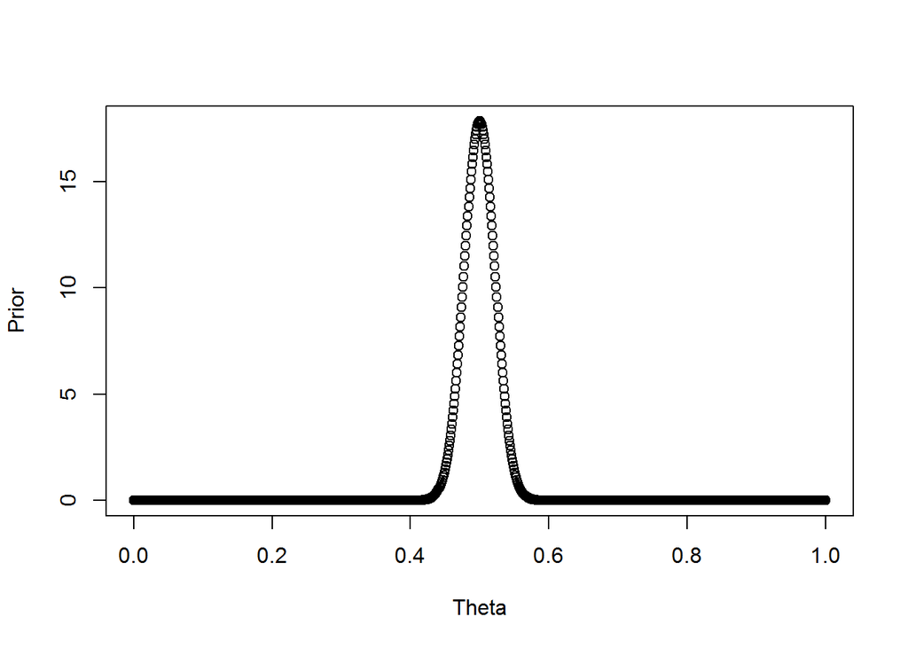

```r
Theta = seq( 0 , 1 , length=1001 )  # Make grid of Theta.
pTheta = dbeta(Theta ,shape1=Prior[1],shape2=Prior[2]) # Beta prior distribution.
plot(Theta,dbeta(Theta ,shape1=Prior[1],shape2=Prior[2]),ylab="Prior")
```

Calculate likelihood for `Data`, given values in `Theta`.

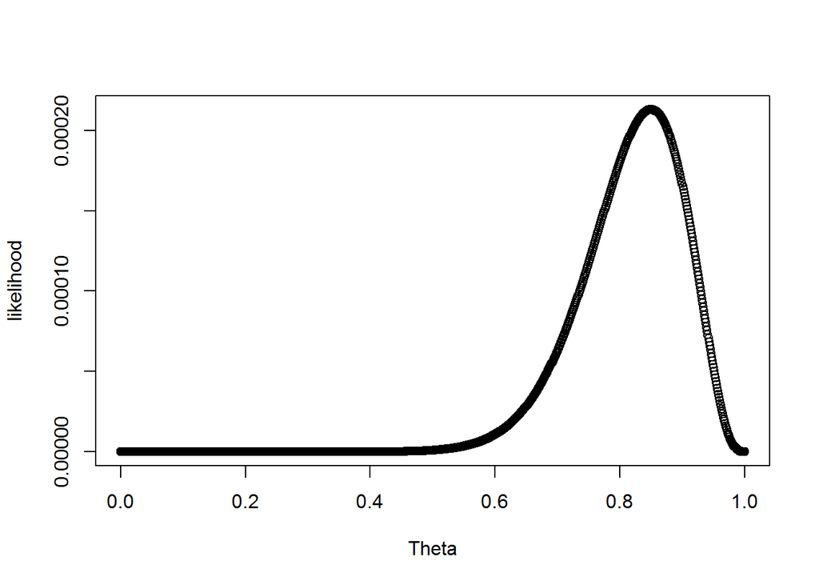

```r
likelihood<-likeli(Theta,Data)
plot(Theta,likelihood)
```

Calculate posterior distribution for $\theta$ using grid approximation.  
You may need to normalize the posterior distribution to make it add up to 1.

(Do it Yourself)

```r
post<-pTheta*likelihood
post<-post/sum(post)*1000
```

Plot the posterior.

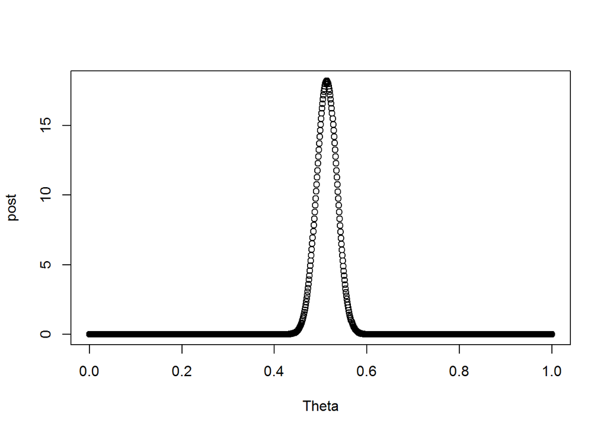

```r
plot (Theta,post)
```

Find the mode of the posterior.

```r
(mode<-Theta[which.max(post)])
```

```
## [1] 0.514
```

Calculate posterior using the analytical formula.

(Do it Yourself)

```r
postBeta<-dbeta(Theta,shape1=z+Prior[1],shape2=N-z+Prior[2])
```

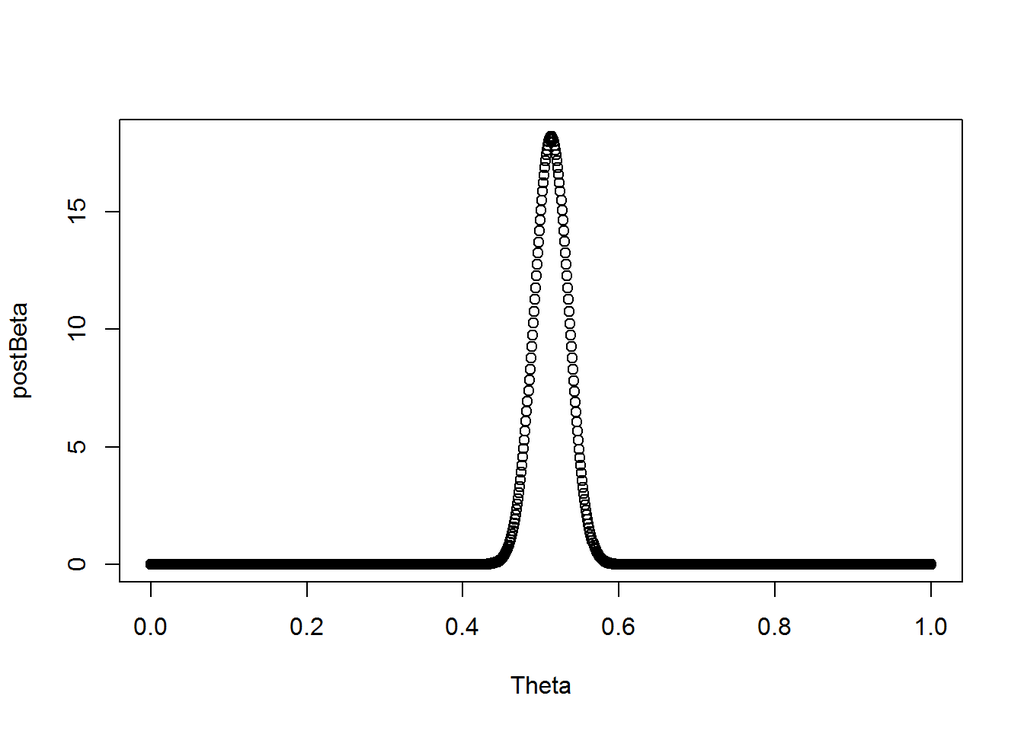

```r
plot(Theta,postBeta)
```

```r
(mode<-Theta[which.max(postBeta)])
```

```
## [1] 0.514
```

Now run the script from the book.

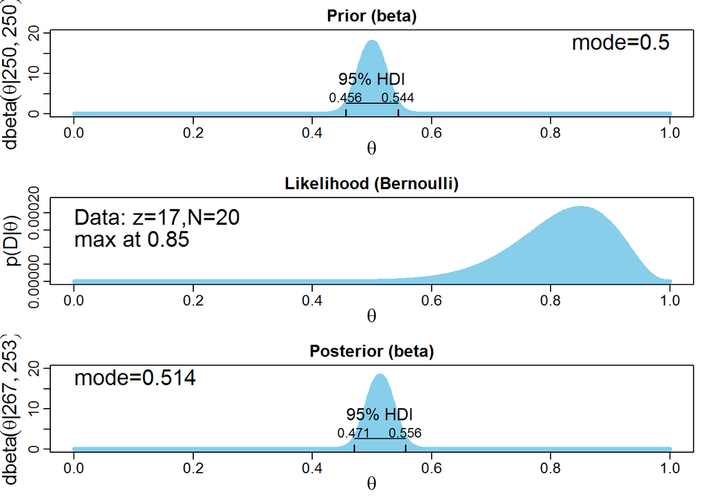

```r
#openGraph(width=5,height=7)
posterior = BernBeta( priorBetaAB=Prior, Data=Data , plotType="Bars" ,
                      showCentTend="Mode" , showHDI=TRUE , showpD=FALSE )
```

```r
#saveGraph(file="BernBetaExample",type="png")
par(mfrow=c(1,1))
```

**Conclusion.**  
Very strong prior knowledge expressed by mode of 0.5 and concentration of 500 could not be affected by a sample of 20 coin flips, even if estimated frequency from these data shows probability of 85% for heads.

## 6.2 Situation 2

A professional basketball player makes 20 free throws.  
We know that professionals tend to make 75% of free throws, majority makes 50% or more, but very few make more than 90%.  
This knowledge is reflected in a beta distribution with mode $\omega=0.75$ and concentration $\kappa=25$.  
Such distribution has 95% highest density interval (HDI) approximately between 0.5 and 0.9.  
**Think how you would define concentration to satisfy the requirement that 95% HDI equals [0.5,0.9]**.

What is your posterior believe this time?

Follow the same steps as in Situation 1.

```r
# Specify the prior:
t = 0.75             # Specify the prior MODE.
n = 25               # Specify the effective prior sample size.
a = t*(n-2) + 1      # Convert to beta shape parameter a.
b = (1-t)*(n-2) + 1  # Convert to beta shape parameter b.
(Prior = c(a,b))       # Specify Prior as vector with the two shape parameters.
```

```
## [1] 18.25  6.75
```

```r
# Specify the data:
N = 20                         # The total number of flips.
z = 17                         # The number of heads.
Data = c(rep(0,N-z),rep(1,z))  # Convert N and z into vector of 0's and 1's.
```

Use formula.

(Do it Yourself)

```r
postBeta<-dbeta(Theta,shape1=z+Prior[1],shape2=N-z+Prior[2])
```

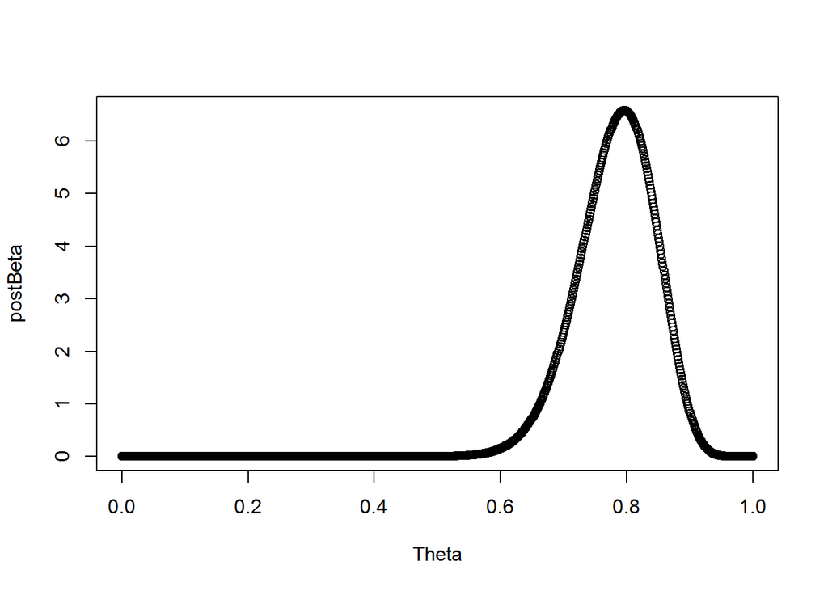

```r
plot(Theta,postBeta)
```

```r
(mode<-Theta[which.max(postBeta)])
```

```
## [1] 0.797
```

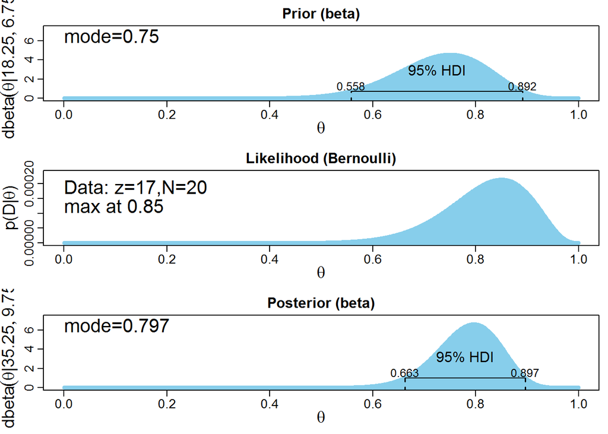

```r
#openGraph(width=5,height=7)
posterior = BernBeta( priorBetaAB=Prior, Data=Data , plotType="Bars" ,
                      showCentTend="Mode" , showHDI=TRUE , showpD=FALSE )
```

```r
#saveGraph(file="BernBetaExample",type="png")
par(mfrow=c(1,1))
```

This time posterior tells us that the result of the observed free throws is much closer to the posterior: observed result is 85% and the posterior mode is 79.7%.  
But we still think that the observed data overestimate the parameter: majority of professional players will show about 75%.

## 6.3 Situation 3

Finally, the third situation described in the book is related to a study of an unknown substance on a remote planet.  
The robot on the surface showed that the substance can be either blue or green.  
Again, out of 20 taken samples 17 are blue.  
There is really no other information about the substance.  
So, a reasonable prior is uniform distribution on [0,1].

```r
# Specify the prior:
a = 1
b = 1
(Prior = c(a,b))       # Specify Prior as vector with the two shape parameters.
```

```
## [1] 1 1
```

```r
# Specify the data:
N = 20                         # The total number of flips.
z = 17                         # The number of heads.
Data = c(rep(0,N-z),rep(1,z))  # Convert N and z into vector of 0's and 1's.
```

Use formula.

(Do it Yourself)

```r
postBeta<-dbeta(Theta,shape1=z+Prior[1],shape2=N-z+Prior[2])
```

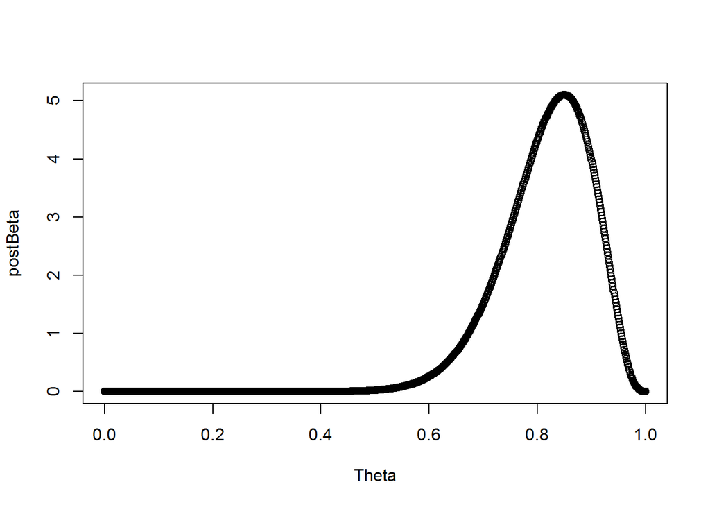

```r
plot(Theta,postBeta)
```

```r
(mode<-Theta[which.max(postBeta)])
```

```
## [1] 0.85
```

Run the analysis.

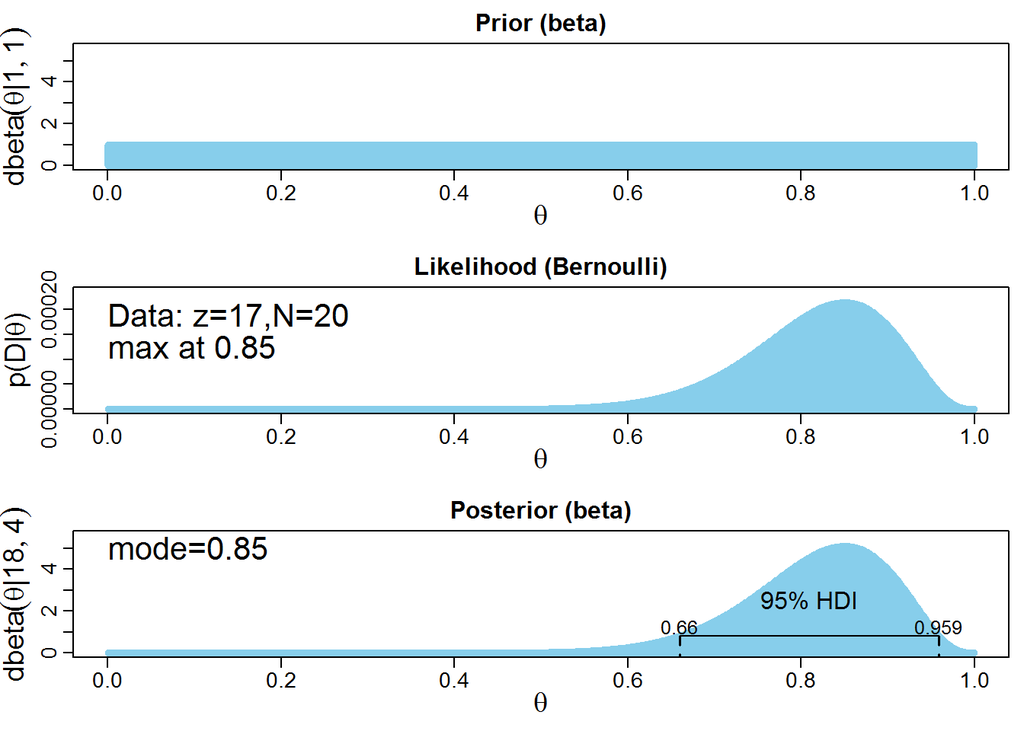

```r
#openGraph(width=5,height=7)
posterior = BernBeta( priorBetaAB=Prior, Data=Data , plotType="Bars" ,
                      showCentTend="Mode" , showHDI=TRUE , showpD=FALSE )
```

```r
#saveGraph(file="BernBetaExample",type="png")
par(mfrow=c(1,1))
```

We see that with as little information as we have we have to rely on the obtained sample: the mode of the posterior distribution is the same as maximum of the sample.

# 7 Exercise 6.2 from [K]

Before an election there is a poll of 100 randomly sampled people of which 58 preferred candidate A and 42 prefer candidate B.  
Which of the candidates is supported by public?

Assume that before the poll prior belief is uniform.  
What is the 95% HDI on the posterior distribution.

(Do it Yourself)

```r
Prior<-c(a=1,b=1)
Data<-c(s=100,k=58)
Posterior<-c(Prior["a"]+Data["k"],Prior["b"]+Data["s"]-Data["k"])
(HDI<-c(qbeta(.025,Posterior["a"],Posterior["b"]),
       qbeta(.975,Posterior["a"],Posterior["b"])))
```

```
## [1] 0.4818182 0.6721301
```

Run `BernBeta()`.

```r
post<-BernBeta(Prior,Data=c(rep(1,58),rep(0,100-58)),showHDI=TRUE,showCentTend="Mode")
```

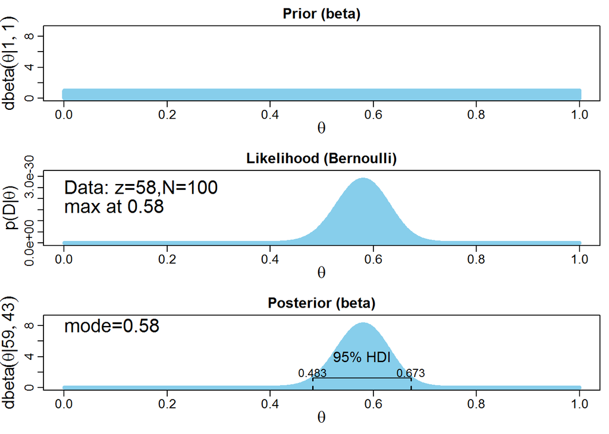

For a follow up poll sample randomly another 100 people. Assume that the new poll results are: 57 prefer candidate A and 43 prefer candidate B.  
What is 95% HDI of the new posterior, assuming that opinions did not change since the first poll?

(Do it Yourself)

```r
Data<-c(s=100,k=57)
Prior<-Posterior
Posterior<-c(Prior["a"]+Data["k"],Prior["b"]+Data["s"]-Data["k"])
(HDI<-c(qbeta(.025,Posterior["a"],Posterior["b"]),
       qbeta(.975,Posterior["a"],Posterior["b"])))
```

```
## [1] 0.5056167 0.6415051
```

Run `BernBeta()`.

```r
post<-BernBeta(Prior,Data=c(rep(1,Data["k"]),rep(0,Data["s"]-Data["k"])),
               showHDI=TRUE,showCentTend="Mode")
```

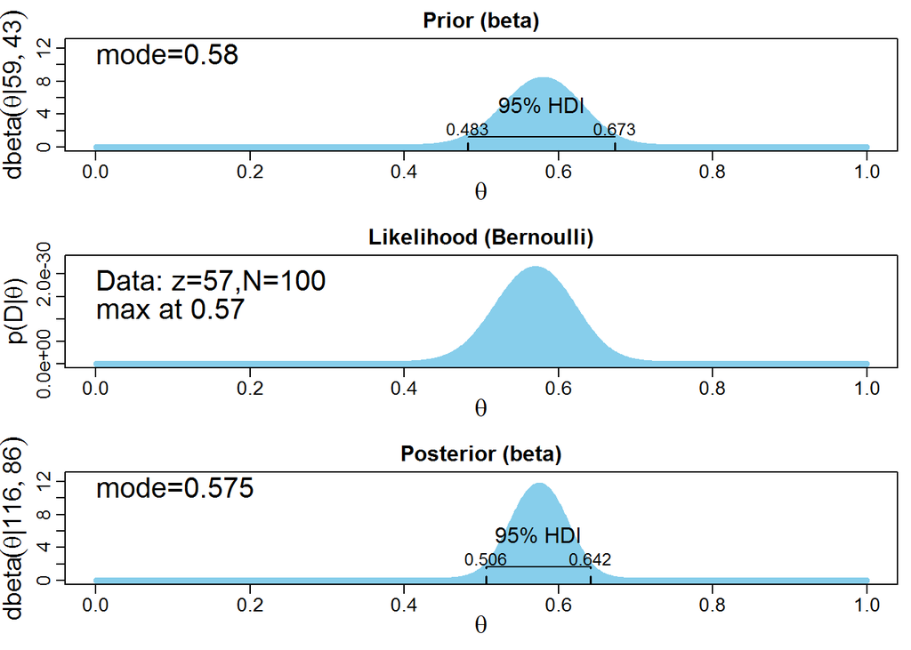

# 8 Predicting binomial probability and Bernoulli outcome

1. Select parameters for the prior distribution, for example, consistent with requirement to observe at least 100 outcomes of independent Bernoulli trials to shift the belief.
2. Create data reproducing the results of the experiment
3. Find posterior distribution of the parameter
4. Find the predicted value of the parameter for an additional animal in the sample
5. Find probability of disease in the next tested animal

(Do it Yourself)

```r
kappa<-100
mu<-.5
alpha<-mu*kappa
beta<-(1-mu)*kappa
data<-c(rep(1,9),rep(0,1))
data.k<-sum(data)
data.s<-length(data)
(alpha.post<-alpha+data.k)
```

```
## [1] 59
```

```r
(beta.post<-data.s-data.k+beta)
```

```
## [1] 51
```

```r
(mean.posterior<-alpha.post/(alpha.post+beta.post))
```

```
## [1] 0.5363636
```

```r
(likelihood.postTheta<-mean.posterior^1*(1-mean.posterior)^0)
```

```
## [1] 0.5363636
```